# TP Markdown

2024-04-02

## Sujet

On pêche des poissons dans le Lez. On suppose qu’il y a en tout 10000 poissons dans le Lez, dont 2000 rouges, 3000 verts et 5000 bleus (le Lez est très pollué). On suppose cependant que l’on n’a pas accès à cette information (on ne sait pas combien il y a de poissons en tout, ni combien de chaque couleur).

## Problématique :

#### **Quelle est la proportion de poissons rouges, verts et bleus dans le Lez ?**

On pêche 100 poissons, que l’on garde pour les exposer en aquarium, et l’on note leur couleur.

**Individus**: poissons

**Population**: les poissons du Lez

**Échantillon**: poissons pêchés

**Taille**: 100

**Variable**: la couleur du poisson

**Modalités**: Rouge / Vert / Bleu

**Type**: qualitative, nominale

Voici la simulation de cette expérience aléatoire :

```r
set.seed(150)
lez <- c(rep("rouge", 2000),           ## 2000 poissons rouges
          rep("bleu", 5000),           ## 5000 poissons bleues
          rep("vert", 3000))           ## 3000 poissons vertes

n_exp <- 100                           ## 100 poissons pêchés

echantillon <- sample(lez,             ## échantillonne les poissons
                      n_exp,           ## n_exp fois
                      replace = FALSE) ## sans remise
```

Et voici un affichage de l’expérience (nombre de fois où chaque boule a été tirée) :

```r
res <- table(echantillon)             ## Résumé de l'échantillon
res
```

```
## echantillon
##  bleu rouge  vert
##    46    17    37
```

Et voici le résultat sous forme de graphique :

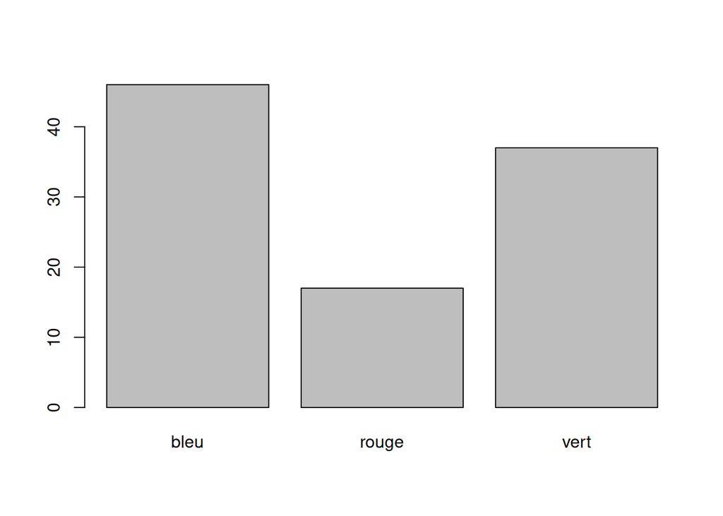

```r
barplot(res)                          ## Diagramme en bar
```

**Résumé :**

Sur les 100 poissons pêchés dans le Lez, on a pêché ici 46 poissons bleus, 17 poissons rouges et 37 poissons verts.

La fréquence empirique du résultat s’approche de la fréquence théorique.

## Conclusion

Si nous répétons l’expérience plusieurs fois ou changeons la taille de l’échantillon, les résultats numériques peuvent varier. L’utilisation de set.seed permet de produire des résultats identiques pour une simulation donnée, car il s’assure que les mêmes nombres aléatoires sont générés à chaque fois.